# Ebola Outbreak Analysis in Sierra Leone

Christopher Nkanta Data Analysis Portfolio Project

2026-10-17

# 1. Introduction

Ebola virus disease (EVD) is a severe infectious disease. The 2014–2016 West African Ebola epidemic had a major impact on Sierra Leone and highlighted the importance of disease surveillance, reliable data collection, and effective public health responses.

This project uses R to explore reported Ebola records from Sierra Leone. The analysis focuses on case status, age, sex, and district. It applies data quality checks, descriptive summaries, frequency tables, and visualizations to describe patterns in the available records.

The objective is to demonstrate how data analysis can support the exploration and communication of public health information. The findings are descriptive and should not be interpreted as estimates of infection risk.

# 2. Dataset Overview

The analysis expects the file `data/ebola_sierra_leone.csv` and uses the following fields:

- `status`: case classification
- `age`: recorded age
- `sex`: recorded sex
- `district`: district associated with the record

Sample of the Sierra Leone Ebola dataset

| id | age | sex | status | date_of_onset | date_of_sample | district |
| --- | --- | --- | --- | --- | --- | --- |
| 92 | 6 | m | confirmed | 2014-06-10 | 2014-06-15 | Kailahun |
| 51 | 46 | f | confirmed | 2014-05-30 | 2014-06-04 | Kailahun |
| 230 | NA | m | confirmed | 2014-06-26 | 2014-06-30 | Kenema |
| 139 | 25 | f | confirmed | 2014-06-13 | 2014-06-18 | Kailahun |
| 8 | 8 | f | confirmed | 2014-05-22 | 2014-05-27 | Kailahun |
| 215 | 49 | m | confirmed | 2014-06-24 | 2014-06-29 | Kailahun |
| 189 | 13 | f | confirmed | 2014-06-19 | 2014-06-24 | Kailahun |
| 115 | 50 | m | confirmed | 2014-06-10 | 2014-06-25 | Kailahun |
| 218 | 35 | f | confirmed | 2014-06-25 | 2014-06-28 | Kenema |
| 159 | 38 | f | confirmed | 2014-06-14 | 2014-06-22 | Kailahun |

Dataset dimensions after removing exact duplicates

| rows | columns |
| --- | --- |
| 200 | 7 |

# 3. Data Preparation and Quality Checks

## 3.1 Missing values

The following summary checks missing values in the key analysis fields.

Missing values in key variables

| missing_status | missing_age | missing_sex | missing_district |
| --- | --- | --- | --- |
| 0 | 4 | 0 | 0 |

## 3.2 Duplicate records

Exact duplicate rows are counted before de-duplication.

Exact duplicate rows in the imported dataset

| exact_duplicate_rows |
| --- |
| 0 |

The cleaned analysis dataset retains one copy of each exact row. This does not establish that records referring to the same person are duplicates; that would require a reliable record identifier and appropriate validation.

# 4. Case Status Analysis

Summarize the number of records in each case-status category.

Records by case status

| status | number_of_records |
| --- | --- |
| confirmed | 182 |
| suspected | 18 |

# 5. Confirmed Cases by Sex

Filter to confirmed records with sex values coded as `f` or `m`, then compare counts.

Confirmed records by recorded sex

| sex | confirmed_cases |
| --- | --- |
| Female | 102 |
| Male | 80 |

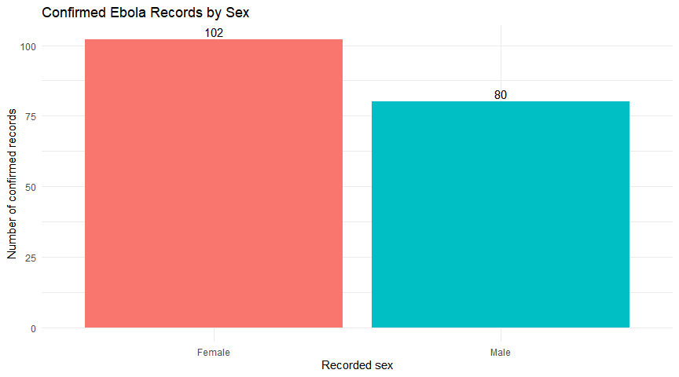

These are counts within the dataset, not sex-specific infection rates. Population denominators and further epidemiological context would be required to compare risk.

# 6. Age Group Analysis

Age is grouped as follows:

- Child: under 18
- Young Adult: 18–29
- Adult: 30 or older
- Unknown: age is missing

Records by age group

| age_group | number_of_records |
| --- | --- |
| Child | 37 |
| Young Adult | 37 |
| Adult | 122 |
| Unknown | 4 |

## 6.1 Confirmed records by age group and sex

Confirmed records by age group and sex

| age_group | sex | confirmed_cases |
| --- | --- | --- |
| Child | Female | 18 |
| Child | Male | 16 |
| Young Adult | Female | 17 |
| Young Adult | Male | 15 |
| Adult | Female | 65 |
| Adult | Male | 48 |
| Unknown | Female | 2 |
| Unknown | Male | 1 |

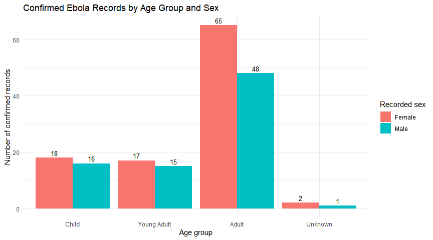

# 7. Geographical Analysis by District

Summarize the number of records associated with each district.

Reported records by district

| district | number_of_records |
| --- | --- |
| Kailahun | 155 |
| Kenema | 34 |
| Western Urban | 4 |
| Bo | 2 |
| Kono | 2 |
| Port Loko | 2 |
| Kambia | 1 |

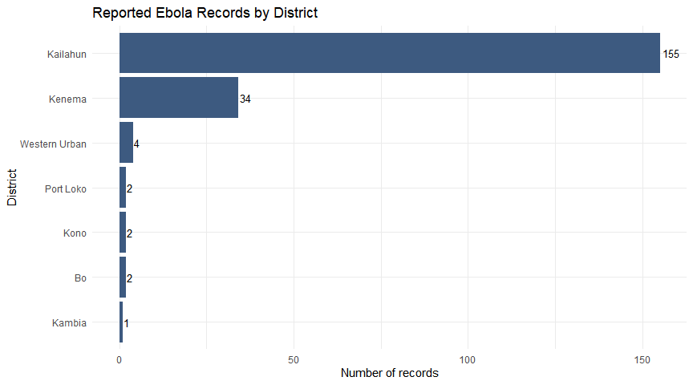

District-level counts describe the distribution of records in this dataset. They should not be treated as district-level rates or direct comparisons of infection risk.

# 8. Categorical Variable Exploration

Use `inspectdf` to examine the distribution of categorical variables.

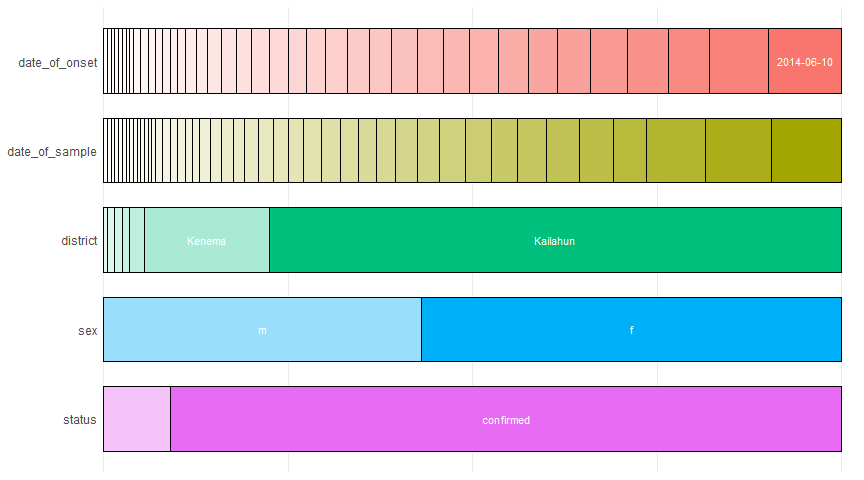

# 9. Conclusion

This project demonstrates an exploratory data analysis workflow in R using reported Ebola records from Sierra Leone. The analysis assesses data quality and explores case classifications, demographic patterns by age and sex, and the geographical distribution of records across districts.

The tables and visualizations provide a descriptive view of the records available in the dataset. They can help identify patterns for further investigation, but they do not establish causes or measure population-level infection risk.

A more complete epidemiological analysis would require additional information, such as population denominators, reporting dates, testing and case definitions, and measures of data completeness. Overall, the project highlights the role of data preparation, descriptive analysis, and visualization in communicating public health data.

# 10. Reproducibility

To reproduce this analysis:

1. Place `ebola_sierra_leone.csv` in the project’s `data/` folder.
2. Open this file in RStudio.
3. Install any packages listed in the setup chunk if needed.
4. Knit the document to HTML.

The results and visualizations in the knitted report are generated from the supplied CSV file.